# Tutorial 4. Differential Expression & Cell-Cell Communication Analysis

Thodoris Koutsandreas, Iguaracy Pinheiro-de-Sousa, Umran Yaman

```r
suppressPackageStartupMessages({
    library(ggplot2)
    library(Seurat)
    library(liana)
    library(dplyr)
})
```

### 1. Loading of the preprocessed snRNA-seq dataset - definition of Idents()

The major.celltype will be selected as ‘Idents’, in order to set the cell types as the main classes of cell. This will help us to run automatically the differential expression analysis for each pathological state (condition) separately (non_AD, early_AD, late_AD), comparing the gene expression profiles of cell type in each condition in order to identify the respective cell type markers.

```r
snRNA_qc_seurat_obj <- readRDS("../data/snRNA_qc_seurat_obj.rds")
# The cell type in meta.data should be a factor
snRNA_qc_seurat_obj$major.celltype <- as.factor(snRNA_qc_seurat_obj$major.celltype)
Idents(snRNA_qc_seurat_obj) <- snRNA_qc_seurat_obj$major.celltype
```

The analysis will be performed for each pathological condition Thus, the dataset should be separated according to this factor.

```r
snRNA_by_condition <- SplitObject(snRNA_qc_seurat_obj, split.by = "Pathology")
```

### 2. Differential expression analysis for each cell type

```r
markers_list <- list()

for (condition in names(snRNA_by_condition)) {

  condition_seurat_obj <- snRNA_by_condition[[condition]]
  cell_types <- unique(condition_seurat_obj@meta.data$major.celltype)

  # Loop through each cell type
  for (cell_type in cell_types) {
    # Check the number of cells in this cell type
    num_cells <- sum(condition_seurat_obj@meta.data$major.celltype == cell_type)
    if (num_cells < 10) {
      next  # Skip to the next cell type
    }
    # Perform differential expression analysis
    markers <- FindMarkers(condition_seurat_obj, ident.1 = cell_type,
      only.pos = TRUE, min.pct = 0.5,
      logfc.threshold = 0.5)
    markers_list[[paste(condition, cell_type, sep = "_")]] <- markers
    print(paste(condition, cell_type, dim(markers)[1]))
  }
}
```

```
## [1] "late_AD Oligodendrocyte_progenitor_cells 487"
## [1] "late_AD Excitatory_neurons 657"
## [1] "late_AD Microglia 499"
## [1] "late_AD Inhibitory_neurons 380"
## [1] "late_AD Oligodendrocytes 470"
## [1] "late_AD Astrocytes 393"
## [1] "late_AD Vascular 173"
## [1] "early_AD Inhibitory_neurons 363"
## [1] "early_AD Excitatory_neurons 447"
## [1] "early_AD Oligodendrocyte_progenitor_cells 494"
## [1] "early_AD Astrocytes 546"
## [1] "early_AD Oligodendrocytes 494"
## [1] "early_AD Vascular 173"
## [1] "early_AD Microglia 477"
## [1] "non_AD Astrocytes 436"
## [1] "non_AD Inhibitory_neurons 490"
## [1] "non_AD Oligodendrocyte_progenitor_cells 492"
## [1] "non_AD Excitatory_neurons 704"
## [1] "non_AD Oligodendrocytes 454"
## [1] "non_AD Microglia 428"
## [1] "non_AD Vascular 144"
```

```r
# Save the markers list in the 'results' folder
dir.create("../results/", showWarnings = FALSE)
saveRDS(markers_list, "../results/dea_results.rds")
```

#### Check the results

```r
names(markers_list)
```

```
##  [1] "late_AD_Oligodendrocyte_progenitor_cells"
##  [2] "late_AD_Excitatory_neurons"
##  [3] "late_AD_Microglia"
##  [4] "late_AD_Inhibitory_neurons"
##  [5] "late_AD_Oligodendrocytes"
##  [6] "late_AD_Astrocytes"
##  [7] "late_AD_Vascular"
##  [8] "early_AD_Inhibitory_neurons"
##  [9] "early_AD_Excitatory_neurons"
## [10] "early_AD_Oligodendrocyte_progenitor_cells"
## [11] "early_AD_Astrocytes"
## [12] "early_AD_Oligodendrocytes"
## [13] "early_AD_Vascular"
## [14] "early_AD_Microglia"
## [15] "non_AD_Astrocytes"
## [16] "non_AD_Inhibitory_neurons"
## [17] "non_AD_Oligodendrocyte_progenitor_cells"
## [18] "non_AD_Excitatory_neurons"
## [19] "non_AD_Oligodendrocytes"
## [20] "non_AD_Microglia"
## [21] "non_AD_Vascular"
```

```r
key = "late_AD_Microglia"
head(markers_list[[key]])
```

|  | p_val | avg_log2FC | pct.1 | pct.2 | p_val_adj |
| --- | --- | --- | --- | --- | --- |
| DOCK8 | 0 | 9.189419 | 0.946 | 0.015 | 0 |
| APBB1IP | 0 | 10.961469 | 0.903 | 0.007 | 0 |
| TBXAS1 | 0 | 8.142016 | 0.912 | 0.023 | 0 |
| FYB1 | 0 | 8.580438 | 0.850 | 0.014 | 0 |
| SLCO2B1 | 0 | 5.790008 | 0.869 | 0.033 | 0 |
| ARHGAP15 | 0 | 6.912714 | 0.863 | 0.039 | 0 |

### 3. Cell-cell communication analysis for each cell type

```r
liana_results <- list()

# Run LIANA for each condition
for (condition in names(snRNA_by_condition)) {
  condition_seurat_obj <- snRNA_by_condition[[condition]]
  liana_results[[condition]] <- liana_wrap(condition_seurat_obj)
}
```

```r
# Check how the results are organised
print(names(liana_results))
```

```
## [1] "late_AD"  "early_AD" "non_AD"
```

```r
print(names(liana_results[["late_AD"]]))
```

```
## [1] "natmi"       "connectome"  "logfc"       "sca"         "cellphonedb"
```

```r
head(liana_results[["late_AD"]]$natmi, 20)
```

| source | target | ligand.complex | ligand | receptor.complex | receptor | receptor.prop | ligand.prop | ligand.expr | receptor.expr | ligand.sum | receptor.sum | prod_weight | edge_specificity |
| --- | --- | --- | --- | --- | --- | --- | --- | --- | --- | --- | --- | --- | --- |
| Oligodendrocyte_progenitor_cells | Oligodendrocyte_progenitor_cells | DLL1 | DLL1 | NOTCH1 | NOTCH1 | 0.2301038 | 0.1660900 | 0.1505182 | 0.2409547 | 0.7760544 | 1.3906702 | 0.0362681 | 0.0336053 |
| Oligodendrocyte_progenitor_cells | Oligodendrocyte_progenitor_cells | DLL1 | DLL1 | NOTCH2 | NOTCH2 | 0.4186851 | 0.1660900 | 0.1505182 | 0.4914967 | 0.7760544 | 2.0303167 | 0.0739792 | 0.0469520 |
| Oligodendrocyte_progenitor_cells | Oligodendrocyte_progenitor_cells | ADAM10 | ADAM10 | TSPAN15 | TSPAN15 | 0.1937716 | 0.4048443 | 0.4870252 | 0.1884083 | 4.5360119 | 1.2567186 | 0.0917596 | 0.0160968 |
| Oligodendrocyte_progenitor_cells | Oligodendrocyte_progenitor_cells | ADAM10 | ADAM10 | AXL | AXL | 0.1401384 | 0.4048443 | 0.4870252 | 0.1476080 | 4.5360119 | 1.7915897 | 0.0718888 | 0.0088460 |
| Oligodendrocyte_progenitor_cells | Oligodendrocyte_progenitor_cells | ADAM10 | ADAM10 | NOTCH1 | NOTCH1 | 0.2301038 | 0.4048443 | 0.4870252 | 0.2409547 | 4.5360119 | 1.3906702 | 0.1173510 | 0.0186032 |
| Oligodendrocyte_progenitor_cells | Oligodendrocyte_progenitor_cells | ADAM10 | ADAM10 | NOTCH2 | NOTCH2 | 0.4186851 | 0.4048443 | 0.4870252 | 0.4914967 | 4.5360119 | 2.0303167 | 0.2393713 | 0.0259917 |
| Oligodendrocyte_progenitor_cells | Oligodendrocyte_progenitor_cells | ADAM10 | ADAM10 | NRCAM | NRCAM | 0.9723183 | 0.4048443 | 0.4870252 | 3.0852466 | 4.5360119 | 8.1853656 | 1.5025928 | 0.0404696 |
| Oligodendrocyte_progenitor_cells | Oligodendrocyte_progenitor_cells | ADAM12 | ADAM12 | ITGB1 | ITGB1 | 0.2698962 | 0.4100346 | 0.5275640 | 0.2811434 | 1.3538278 | 2.1131600 | 0.1483211 | 0.0518450 |
| Oligodendrocyte_progenitor_cells | Oligodendrocyte_progenitor_cells | ADAM12 | ADAM12 | ITGA9 | ITGA9 | 0.3719723 | 0.4100346 | 0.5275640 | 0.4522688 | 1.3538278 | 2.1575056 | 0.2386007 | 0.0816877 |
| Oligodendrocyte_progenitor_cells | Oligodendrocyte_progenitor_cells | SLITRK3 | SLITRK3 | PTPRD | PTPRD | 0.8996540 | 0.2283737 | 0.2372286 | 2.1453245 | 0.4582235 | 12.1461897 | 0.5089323 | 0.0914414 |
| Oligodendrocyte_progenitor_cells | Oligodendrocyte_progenitor_cells | SLITRK3 | SLITRK3 | PTPRS | PTPRS | 0.4792388 | 0.2283737 | 0.2372286 | 0.5992724 | 0.4582235 | 3.4105392 | 0.1421646 | 0.0909685 |
| Oligodendrocyte_progenitor_cells | Oligodendrocyte_progenitor_cells | SLITRK5 | SLITRK5 | PTPRD | PTPRD | 0.8996540 | 0.3650519 | 0.4081164 | 2.1453245 | 1.5863658 | 12.1461897 | 0.8755422 | 0.0454395 |
| Oligodendrocyte_progenitor_cells | Oligodendrocyte_progenitor_cells | TGFA | TGFA | ERBB3 | ERBB3 | 0.2923875 | 0.3235294 | 0.3466996 | 0.3003044 | 0.6882870 | 0.8947544 | 0.1041154 | 0.1690603 |
| Oligodendrocyte_progenitor_cells | Oligodendrocyte_progenitor_cells | TGFA | TGFA | ERBB4 | ERBB4 | 0.9844291 | 0.3235294 | 0.3466996 | 3.2323473 | 0.6882870 | 12.9483545 | 1.1206535 | 0.1257440 |
| Oligodendrocyte_progenitor_cells | Oligodendrocyte_progenitor_cells | HLA-A | HLA-A | APLP2 | APLP2 | 0.3217993 | 0.2923875 | 0.3580612 | 0.3453511 | 2.0107925 | 3.0212102 | 0.1236568 | 0.0203549 |
| Oligodendrocyte_progenitor_cells | Oligodendrocyte_progenitor_cells | APP | APP | TNFRSF21 | TNFRSF21 | 0.3096886 | 0.7958478 | 1.5048737 | 0.3512820 | 8.3838344 | 0.9412400 | 0.5286350 | 0.0669904 |
| Oligodendrocyte_progenitor_cells | Oligodendrocyte_progenitor_cells | APP | APP | LRP6 | LRP6 | 0.4740484 | 0.7958478 | 1.5048737 | 0.5585781 | 8.3838344 | 2.7116665 | 0.8405895 | 0.0369747 |
| Oligodendrocyte_progenitor_cells | Oligodendrocyte_progenitor_cells | APP | APP | TSPAN15 | TSPAN15 | 0.1937716 | 0.7958478 | 1.5048737 | 0.1884083 | 8.3838344 | 1.2567186 | 0.2835308 | 0.0269104 |
| Oligodendrocyte_progenitor_cells | Oligodendrocyte_progenitor_cells | APP | APP | RPSA | RPSA | 0.1799308 | 0.7958478 | 1.5048737 | 0.1934888 | 8.3838344 | 1.6239845 | 0.2911762 | 0.0213861 |
| Oligodendrocyte_progenitor_cells | Oligodendrocyte_progenitor_cells | APP | APP | GPC1 | GPC1 | 0.1833910 | 0.7958478 | 1.5048737 | 0.1890470 | 8.3838344 | 1.3168271 | 0.2844919 | 0.0257691 |

#### Aggregation of liana results for each condition

The liana_results list contains the results of different methods for each pathological condition. In the block below, all the results are aggregated to create a single data frame for each condition, which includes the most significant ligand-receptor interactions for each pair of cell types.

```r
aggregated_liana_results <- list()
# Process and save results for each subset
for (condition in names(liana_results)) {
    # Aggregate results
    aggregated_liana <- liana_results[[condition]] %>%
        liana_aggregate()
    # Filter results - keep the most significant
    filtered_liana <- aggregated_liana %>%
        dplyr::filter(aggregate_rank <= 0.05)
    aggregated_liana_results[[condition]] <- filtered_liana
}

# Save the results list in the 'results' folder
saveRDS(aggregated_liana_results, "../results/ccc_results.rds")
```

#### Visualization of cell-cell interactions

Interactions of Microglia cells with the other cell types in healthy state.

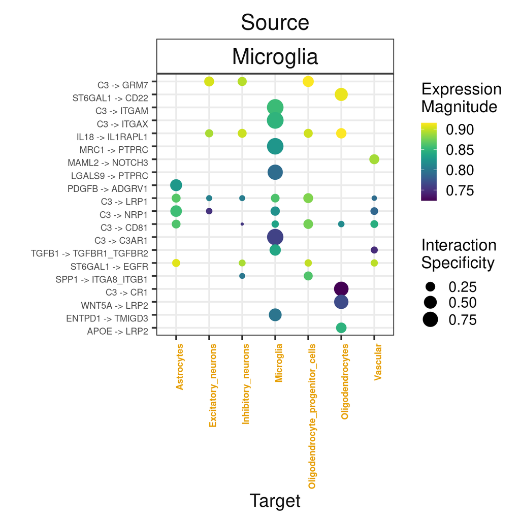

```r
cell_type_of_interest <- "Microglia"

p <- liana_dotplot(
  aggregated_liana_results$non_AD,
  source_groups = c(cell_type_of_interest),  # Adjust this based on how your cell types are categorized (source or target)
  target_groups = NULL,  # Adjust target groups as needed or based on your specific analysis requirements
  ntop = 20,  # Assuming you want the top 20 interactions
  size_range = c(1, 8),
  y.label = '',
) + theme(axis.text.x = element_text(angle = 90, size=10, hjust=1),
          axis.text.y = element_text(size=10, vjust=1),
          )
p
```

Interactions of Microglia cells with the other cell types in late AD.

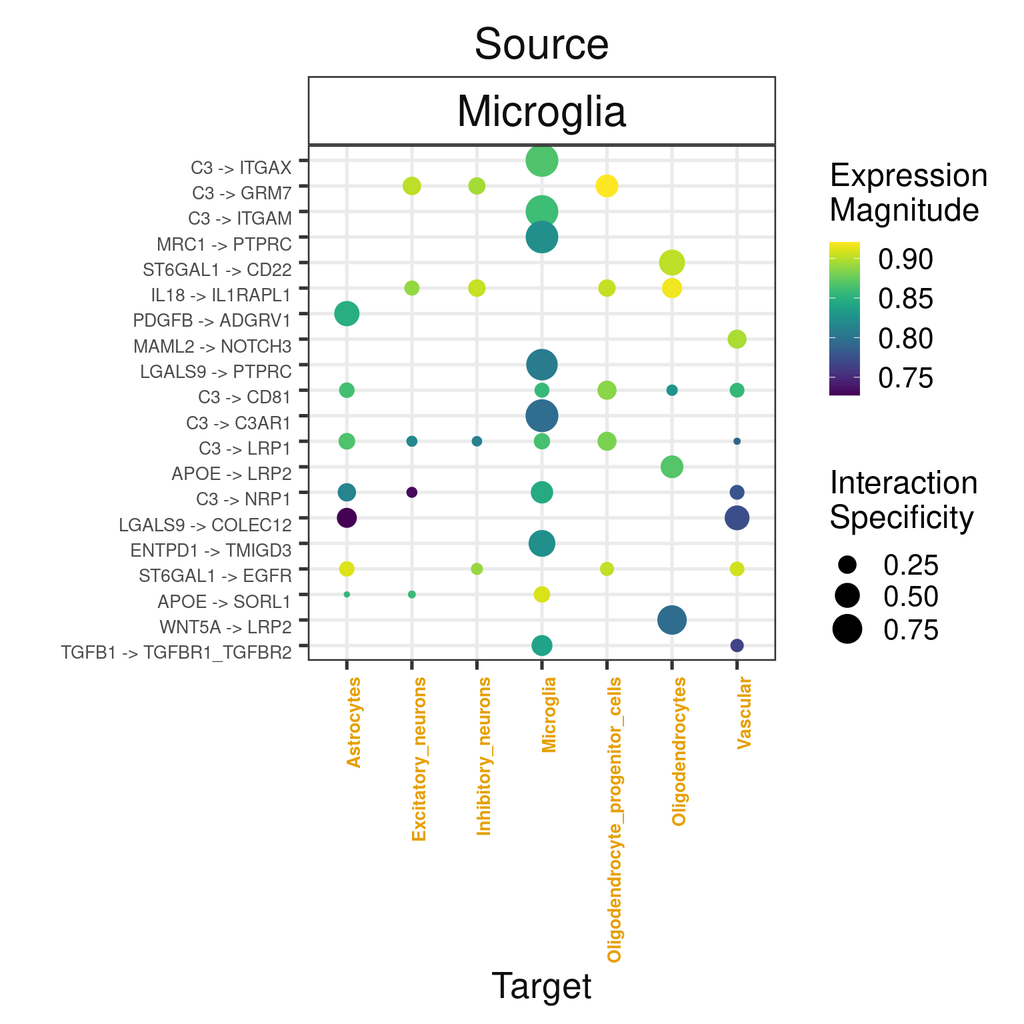

```r
cell_type_of_interest <- "Microglia"

p <- liana_dotplot(
  aggregated_liana_results$late_AD,
  source_groups = c(cell_type_of_interest),  # Adjust this based on how your cell types are categorized (source or target)
  target_groups = NULL,  # Adjust target groups as needed or based on your specific analysis requirements
  ntop = 20,  # Assuming you want the top 20 interactions
  size_range = c(1, 8),
  y.label = '',
) + theme(axis.text.x = element_text(angle = 90, size=10, hjust=1),
          axis.text.y = element_text(size=10, vjust=1),
          )
p
```